# Light

# Light casts light and shadows onto a 3D scene

Lights illuminate surfaces to add highlights and atmosphere to scenes. You can use lights to create atmosphere and guide players to the intended path.

Shadows can add character to a location and limit player visibility in dark areas.

This guide also covers `GIProbe` and `BakedLightmap`, which rely on other `Light` nodes in the scene to show off their features.

In this guide, we’ll show you how to:

- Light a scene.
- Adjust and animate lights.
- Make a light react to player input.
- Create a day-night cycle with real-time shadows.

Contents:

Contents:

- Overview of Light nodes
- Setting up a Light
- Light’s key features
- How to use a Light in practice
  - Lighting an outdoor scene
  - Creating a day-night cycle
  - Lighting an interior scene
  - Making a flashlight
  - Shooting out lights with a gun
  - Triggering light on gunfire
- Your questions
  - What are the major differences between all the lighting options?
  - Which lighting option is best for my project?
  - Where can I learn more about materials?
- Troubleshooting
  - Shadow Issues
  - BakedLightmap Bugs
  - Dynamic Lighting Bugs
- Pro Tips

## Overview of Light nodes

Here is a quick overview of all the available light nodes:

- `OmniLight`
- `SpotLight`
- `DirectionalLight`
- `GIProbe`
- `BakedLightmap`

`OmniLight` emits light in a sphere away from its position.

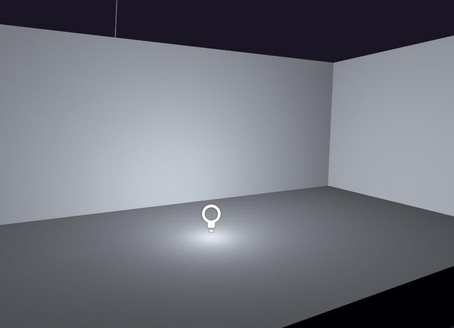

`SpotLight` emits light in a cone from its position.

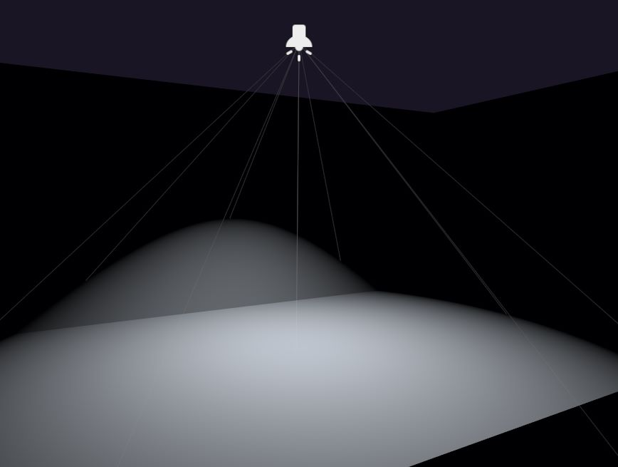

`DirectionalLight` emits light across the entire scene. Its rotation determines the light and shadow direction. Ideally, there only needs to be one `DirectionalLight` per scene. This light is ideal for simulating sunlight or making simple scene-wide lighting.

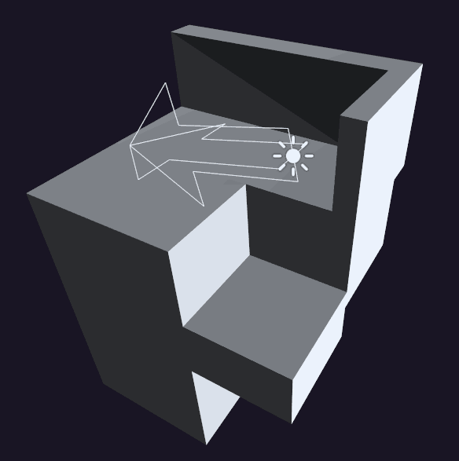

`GIProbe` creates real-time global illumination. It bakes indirect light from geometry with the *Use In Baked Light* property enabled and projects it onto dynamic objects. It looks great but runs the slowest of all the lighting options.

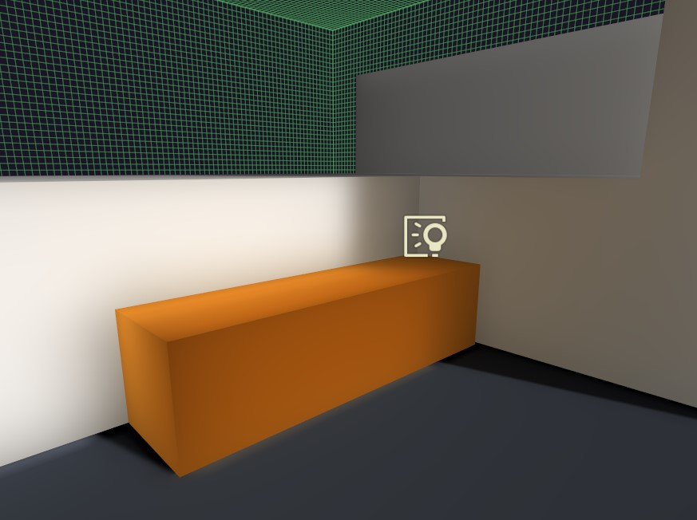

`BakedLightMap` creates pre-calculated, raytraced lighting. Using other lights, it creates textures known as lightmaps to add lighting details on top of mesh textures. It’s pre-calculated and runs fast in-game, at the cost of increasing your project’s file size.

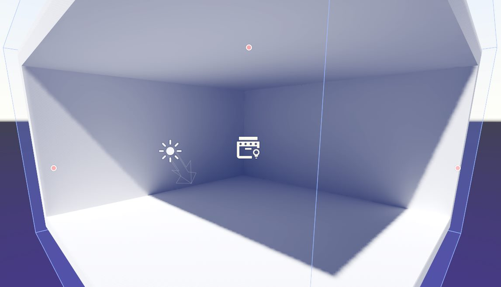

## Setting up a Light

Besides adding any of the above light nodes, all light needs geometry to reflect the light. You can use `MeshInstance` and its `Mesh` resource to get geometry for your level.

You can then add a light such as `OmniLight`, and enable shadows by setting *Shadow -> Enabled* to true.

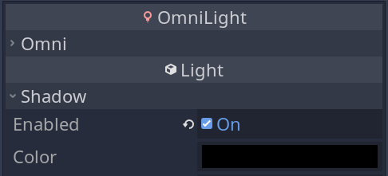

Shadows need a surface to appear on. You can create a simple surface using a `MeshInstance` with a plane mesh. Then have other meshes above to cast shadows onto the plane.

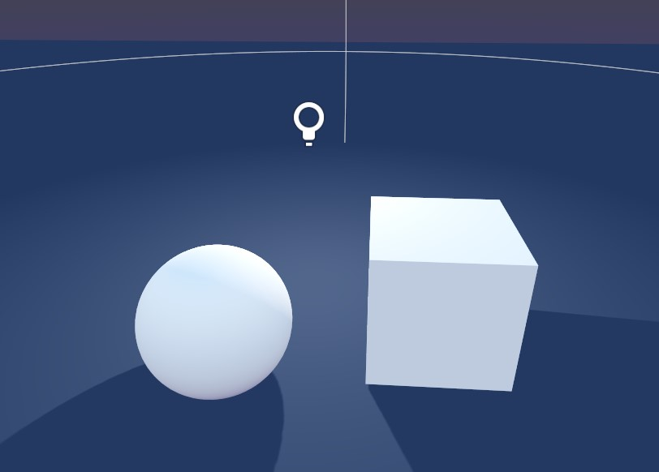

## Light’s key features

Here are some key features to use when using any light in 3D.

*Energy* determines the strength of the light, which you can animate to create flickering effects.

`0.5` *Energy*

`2.5` *Energy*

`10.0` *Energy*

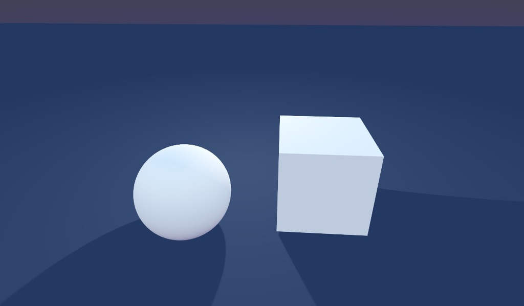

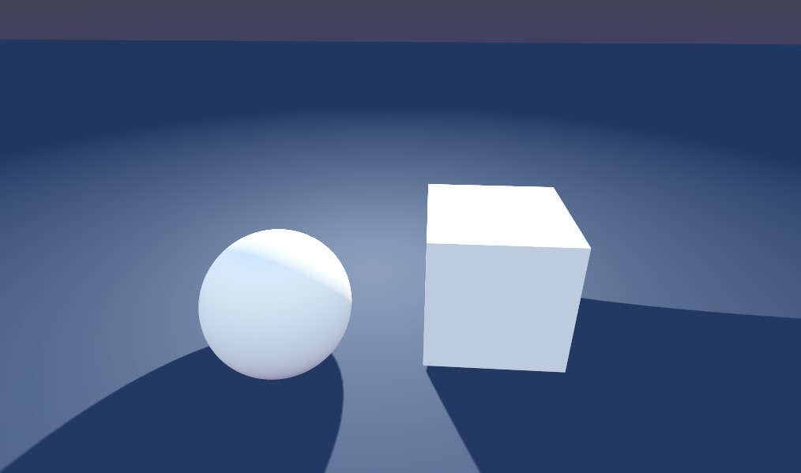

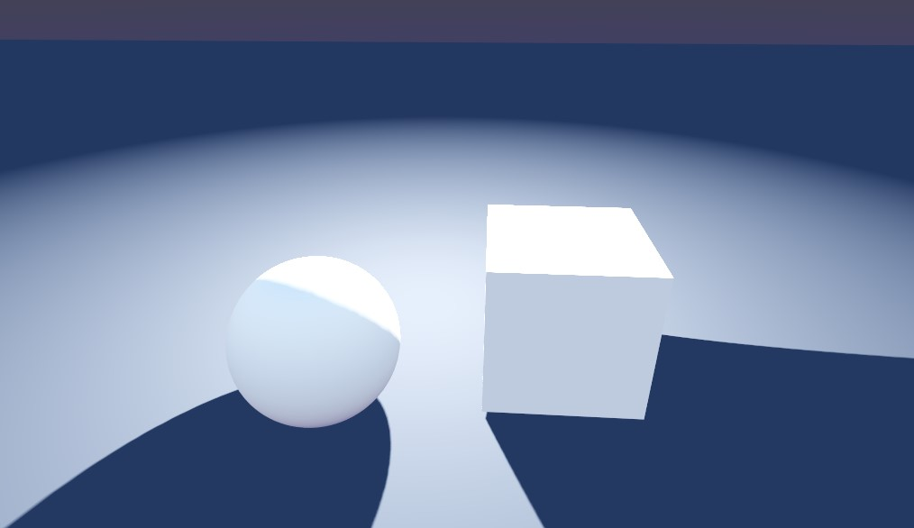

*Color* changes the light color cast onto the world. A more-saturated color drastically affects the appearance of surrounding materials.

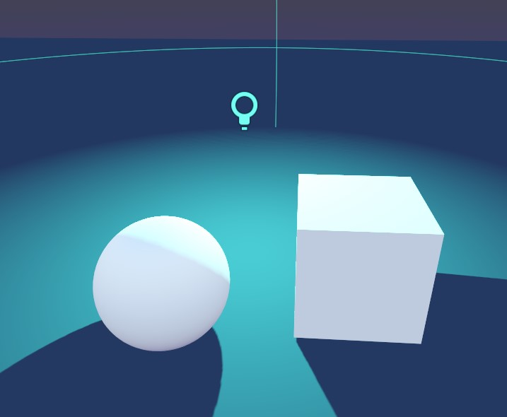

*Shadow -> Enabled* casts dynamic shadows behind objects. Dynamic shadows reduce performance but prevent light from reaching interior areas.

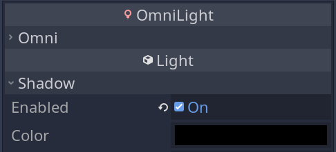

Shadows have many properties. You can find specifics about shadows in Troubleshooting.

*Energy*, *Shadow*, and *Color* are properties available to all light nodes.

**Note:** The following properties only apply to `OmniLight` and `SpotLight`:

*Range* determines how far the light reaches. It also affects how far shadows can reach within the light’s bounds.

*Range* `5`

*Range* `10`

*Range* `60`

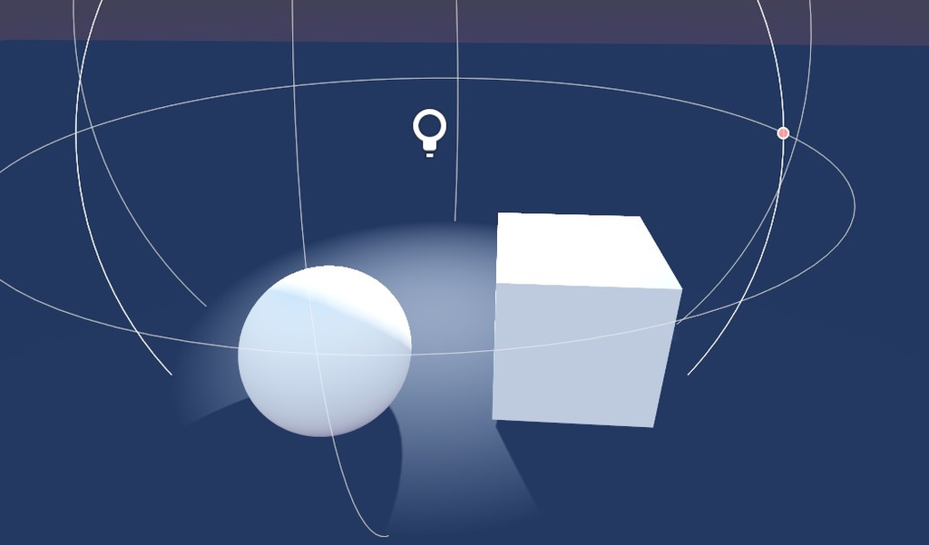

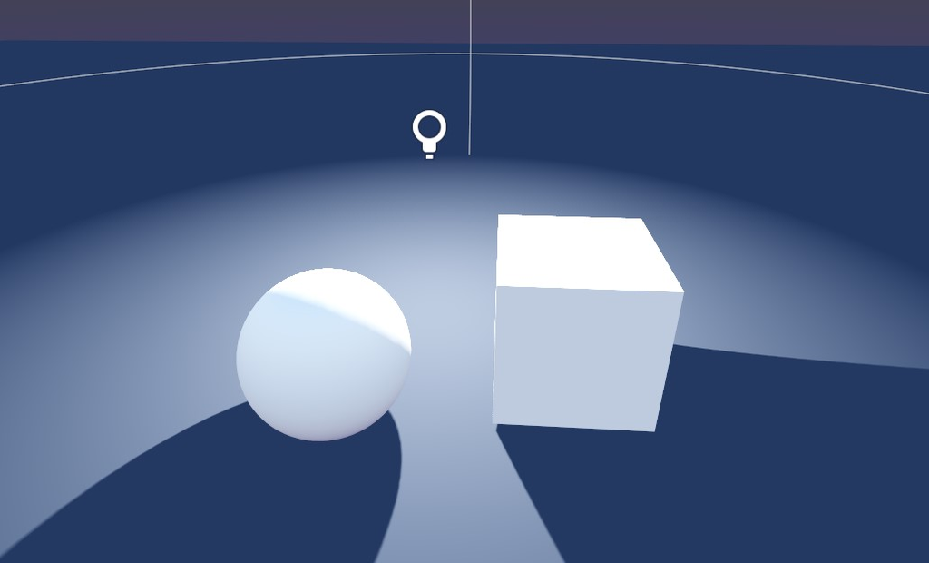

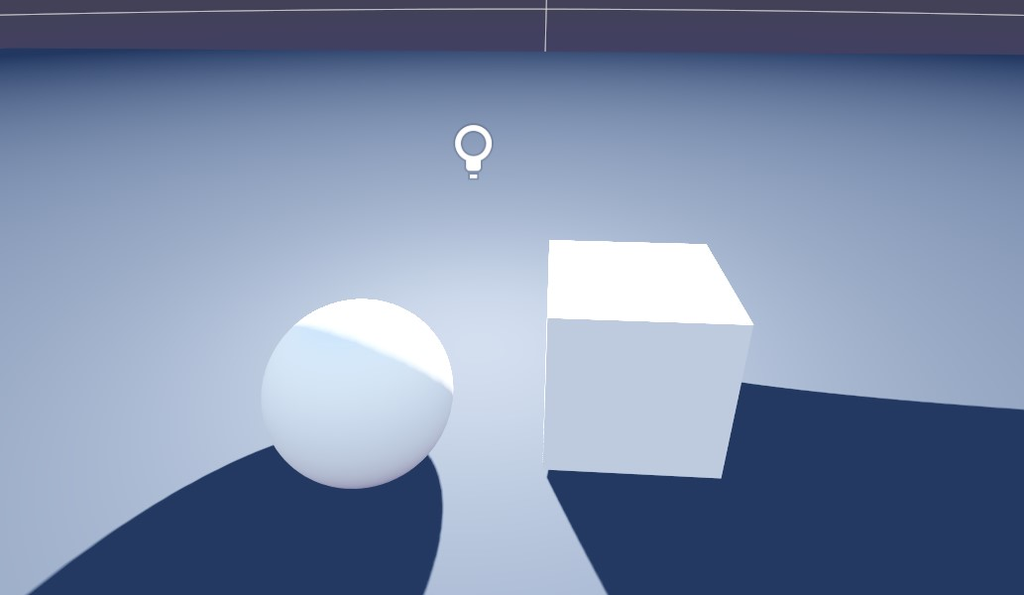

*Attenuation* is a curve that changes how the light fades out as it approaches the light’s *Range*.

*Attenuation* `1`

*Attenuation* `0.1`

*Attenuation* `5`

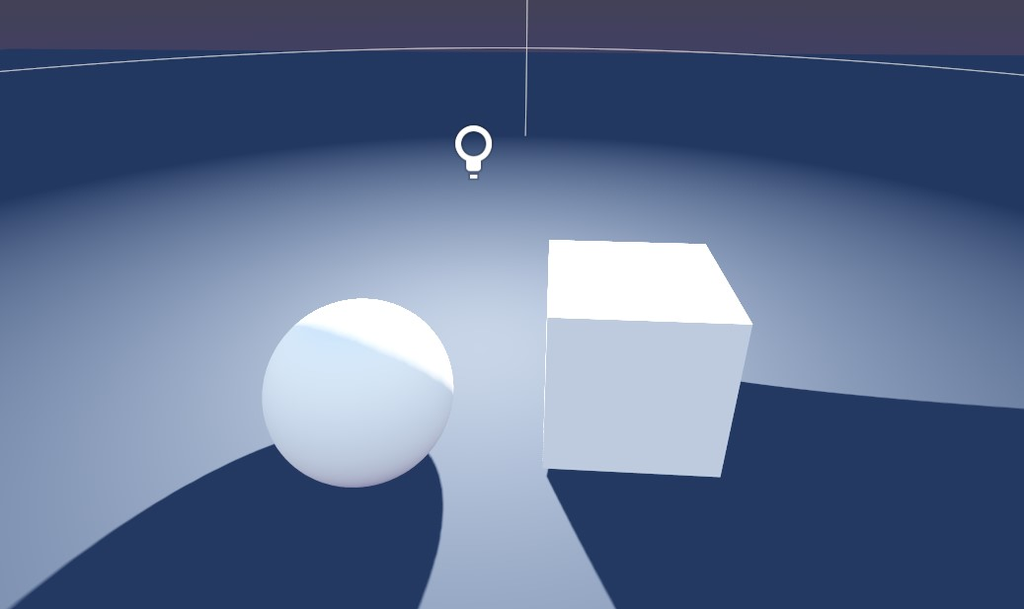

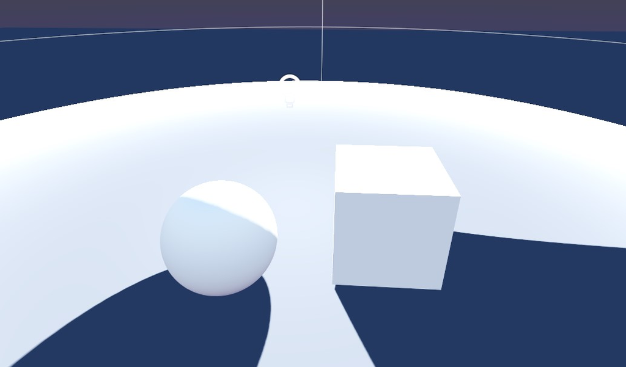

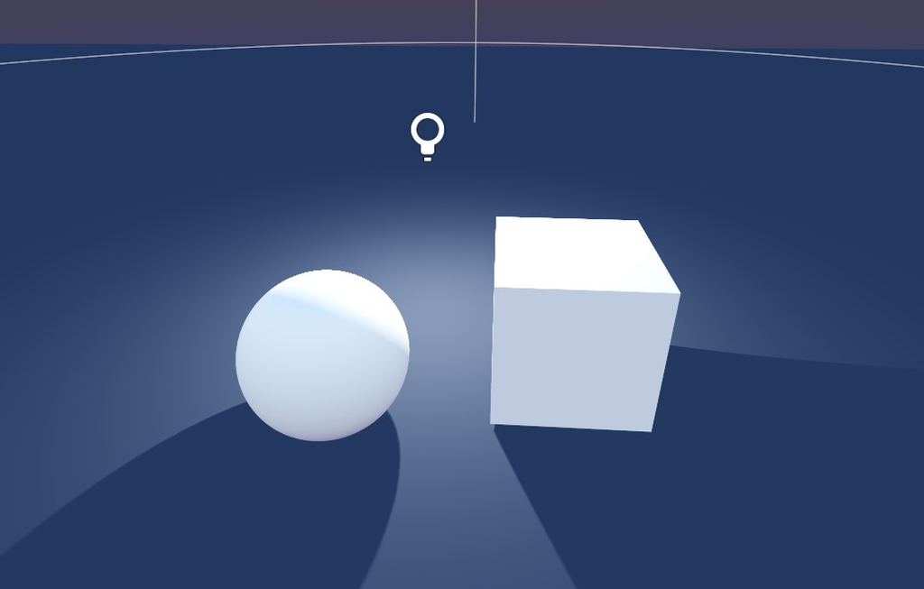

**Note:** Nodes extending the class `Light` are dynamic lights. Unlike static lights, you can move these lights and the surrounding world updates to match. You can only produce dynamic shadows from dynamic lights.

## How to use a Light in practice

Now we can look at some concrete examples of using lights in a 3D scene.

### Lighting an outdoor scene

`DirectionalLight` is ideal for representing sunlight. If your scene has a `WorldEnvironment` with a `ProceduralSky` or a `PanoramaSky`, you can use the 3D viewport to align the `DirectionalLight` to the sun’s angle.

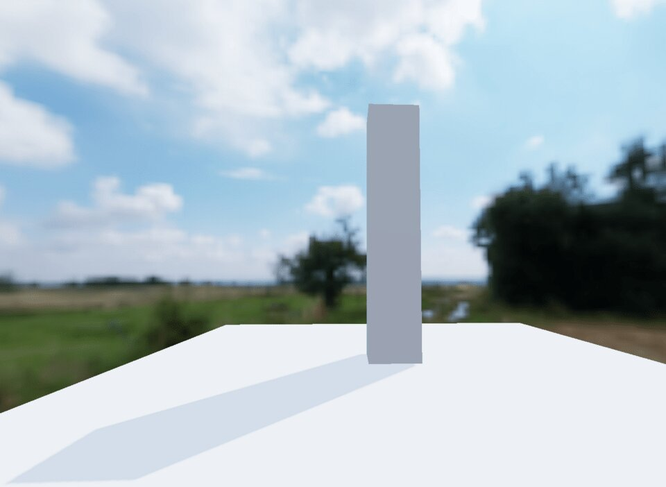

To align the `DirectionalLight` to the sun, select the `DirectionalLight`, move the `Camera`, so the sun is in the center of the screen, then select *Align Rotation With View* in the *Perspective* menu in the *3D Viewport*:

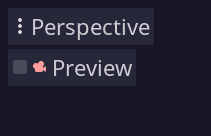

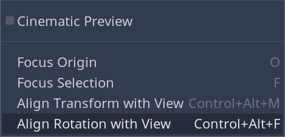

You can also press `Ctrl`+`Alt`+`F` as a shortcut for the same operation.

Lastly, you need to offset `DirectionalLight` by `180` degrees, which points at the ground rather than toward the sun.

You can also enable shadows, so the sun’s direction casts shadows onto the scene.

### Creating a day-night cycle

Some games like *Breath of the Wild* and *Grand Theft Auto* show the passage of time with a day-night system. The strength, color, and direction of the lighting change as time passes.

In Godot, you can simulate changing sunlight during the day using a `DirectionalLight` and an `AnimationPlayer`.

Creating animation tracks on the *Rotation*, *Light Color*, and *Light Energy* properties of a `DirectionalLight` lets you decide the sun angle, color, and strength during the day.

You can create a short looping animation and use the `AnimationPlayer` playback speed to slow it down.

We chose an animation length of twenty-four seconds, so each second represents an hour of the day. This scale makes it easier to apply real-world references of color and time to the system.

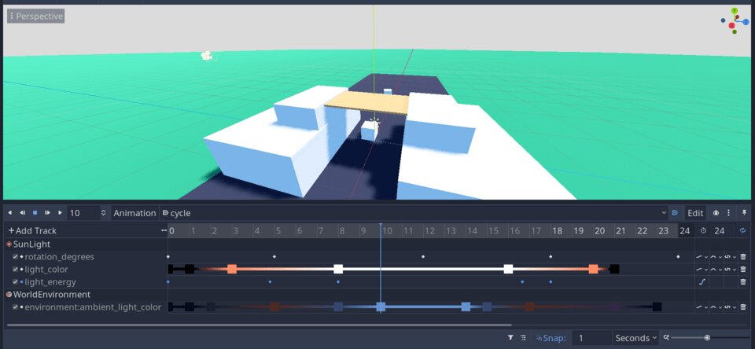

The angles we used for the sun are as follows:

- `0` seconds - `Vector3(90, 20, 0)`
- `6` seconds - `Vector3(0, 20, 0)`
- `12` seconds - `Vector3(-90, 20, 0)`
- `18` seconds - `Vector3(-180, 20, 0)`
- `24` seconds - `Vector3(-270, 20, 0)`

The rotation of `20` degrees on the y-axis acts as our sun’s longitude, so the shadows don’t align with the world’s z-axis. The increments of `90` degrees make the sun rotate consistently without the need for quaternions or code.

The sunlight and ambient light colors are up to you, depending on your game’s visual design. You can see the demo project for exact values.

Another challenge is getting the sun in the sky.

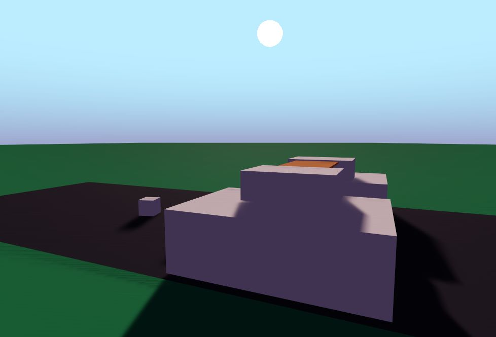

You can enable shadows on this `DirectionalLight` to get shadows that match the sun’s angle.

The final step for a convincing day-night system is to change the color of the sky. We can use a `Viewport` with a `ColorRect` using a GLSL shader to create a sky that quickly changes color.

A `ProceduralSky` resource isn’t fit for this job since it’s less customizable and is slow to update every frame. We chose a `PanoramaSky` with a `ViewportTexture` instead to utilize the speed of GLSL shaders.

As shown below, using a `Viewport` creates a render target. The `ColorRect` renders the GLSL shader.

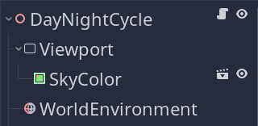

The `PanoramaSky` resource in a `WorldEnvironment` can point to a `ViewportTexture` to create a dynamic sky.

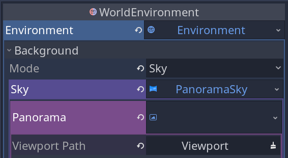

The GLSL shader can expose two colors for us to change in code.

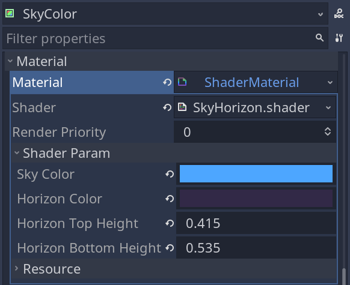

Here is the shader we used on the `ColorRect`:

```
shader_type canvas_item;

uniform vec4 sky_color: hint_color = vec4(1.0);
uniform vec4 horizon_color: hint_color = vec4(vec3(0.48),1.0);

uniform float horizon_top_height = 0.35;
uniform float horizon_bottom_height = 0.4;

void fragment(){
    // Only the top half of the shader is above the 3D horizon.
    float compressed_y = smoothstep(horizon_top_height, horizon_bottom_height, UV.y);

    vec3 sky = mix(sky_color.xyz, horizon_color.xyz, vec3(compressed_y));
    COLOR = vec4(sky, 1.0);
}
```

Then using GDScript in the main scene, we can update the shader parameters to match the colors set earlier on the `AnimationPlayer`.

```
onready var _camera_pivot: Spatial = $CameraPivot

onready var _sky_shader: ShaderMaterial = $Viewport/SkyColor.material
onready var _environment: Environment = $WorldEnvironment.get_environment()
onready var _sun_light: DirectionalLight = $SunLight
onready var _sun_sprite: MeshInstance = $SunLight/Sun


func _process(delta: float) -> void:
    _sun_sprite.get_active_material(0).albedo_color = _sun_light.get_color()

    var ambient_light_color: Color = _environment.get_ambient_light_color()
    _sky_shader.set_shader_param("sky_color", ambient_light_color.lightened(0.8))
    _sky_shader.set_shader_param("horizon_color", ambient_light_color)

    _camera_pivot.rotate_y(ROTATION_SPEED * delta)
```

More `AnimationPlayer` tracks could replace this code, but maintaining two sets of colors for sunlight and ambient light is enough to get a decent-looking result.

**Note:** Godot offers a `ProceduralSky` resource to generate a sky texture. However, updating a `ProceduralSky` is performance-intensive and not adapted to real-time use.

To learn more about using `Viewport` and `ViewportTexture`, check out the Viewport guide.

### Lighting an interior scene

In real life, light bounces around objects, transferring their color to nearby surfaces and creating subtle light gradients in shadowed areas.

The `GIProbe` node helps you simulate that in your games, including on moving objects. The `GIProbe` pre-calculates light information in a game area and allows the graphics engine to fake light bounces at a reasonable performance cost.

On the image below, notice the red and yellow leaking onto the wall.

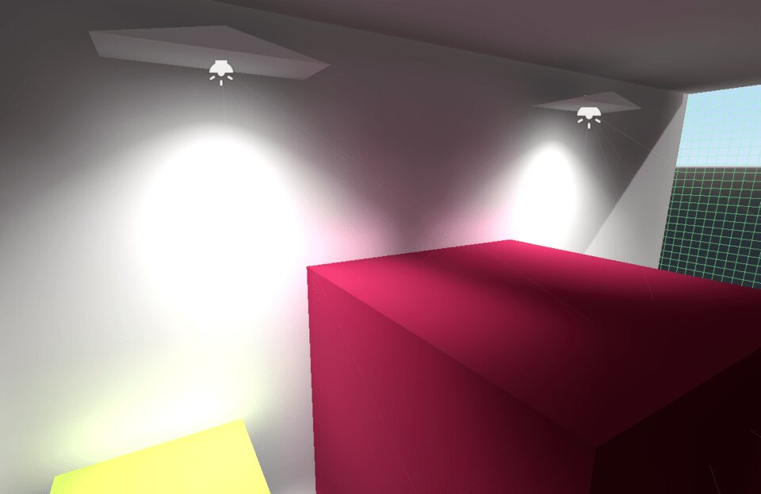

Compared to `BakedLightmap`, `GIProbe` gives higher-quality results with smaller file sizes, and it also works on moving objects. However, the catch is `GIProbe` requires more graphics processing power compared to `BakedLightmap`.

If you add a `GIProbe` without any setup, it only changes the dynamic range of nearby lights. Its power comes from blending static lighting with dynamic lighting.

To use `GIProbe`’s static lighting, add the node to a scene and adjust its *Extents* to fit the area to light up.

You need to enable *Baked Light -> Use In Baked Light* on every static mesh that should contribute to the global illumination.

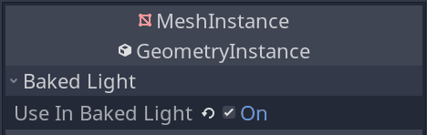

Then you can select the `GIProbe` again and click *Bake GI Probe* in the *Toolbar* to begin the bake.

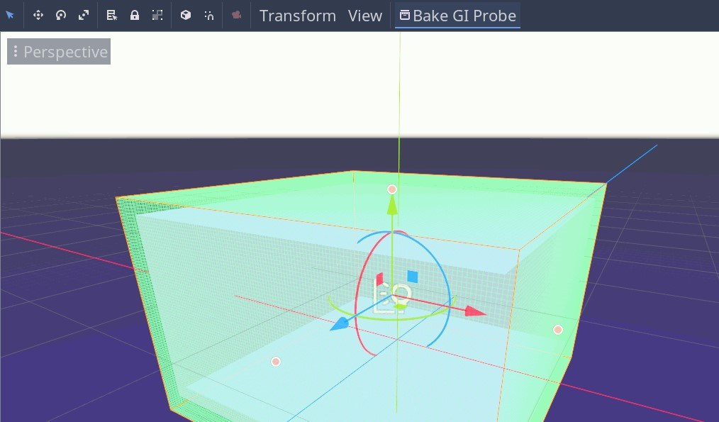

Static lighting only remains accurate if all the baked lights and meshes don’t move. If you move any baked meshes, the scene’s lighting can appear incorrect.

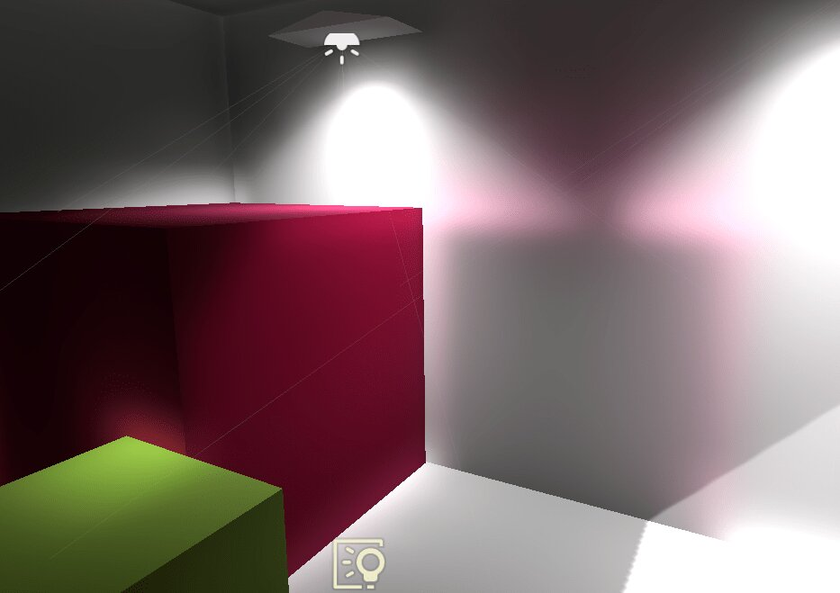

If you update your levels’ design, you’ll need to bake the corresponding GI probes again.

You can use GI probes for indoor and outdoor scenes. However, the *Extents* box makes it easier to segment indoor scenes into several probes: one probe per room.

Enabling the *Interior* property removes the energy from the sky in its light calculations. `GIProbe` nodes account for any `DirectionalLight` in the scene set to bake so that you can get sunlight in an interior scene like the one shown below.

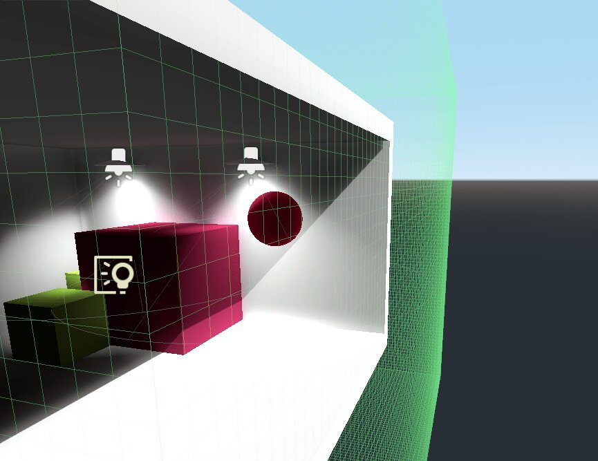

You can edit the scale of this box with the *Extents* property, and move the `GIProbe` to adjust its position.

The lighting quality gets lower with larger *Extents*, but you can regain the quality lost from having larger extents by increasing the *Subdiv* property. It is worth noting you don’t need a `GIProbe` to cover your whole level, and you can use multiple probes just in areas of interest.

After setting the bounds of a `GIProbe` or `BakedLightmap`, you can temporarily hide the appearance of bounds using the *View -> Gizmos* menu in the *Toolbar*.

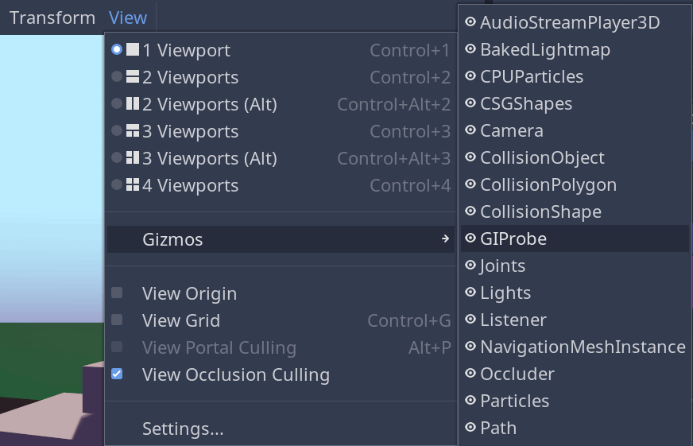